# The Strategy Frequency Estimation Method

James R Bland (https://sites.google.com/site/jamesbland/)

February 4, 2020

One of the econometric models that most sparked my interest was the Strategy Frequency Estimation Method (SFEM), which first showed up in the following papers:

> Dal Bó, Pedro, and Guillaume R. Fréchette. “The evolution of cooperation in infinitely repeated games: Experimental evidence.” American Economic Review 101, no. 1 (2011): 411-29.

> Fudenberg, Drew, David G. Rand, and Anna Dreber. “Slow to anger and fast to forgive: Cooperation in an uncertain world.” American Economic Review 102, no. 2 (2012): 720-49.

In these applications, and a lot that followed, the SFEM is applied to data from infinitely repeated Prisoner’s Dilemma experiments. In these games, strategies can be quite complicated beasts, because they must prescribe an action to take after every possible history of play, and histories in an infinitely repeated game can be, well … infinite.

The simplifying assumption that the SFEM makes is that there is a fixed menu of strategies that players may choose, and that they stick to one for the entire experiment. For example, Dal Bó and Fréchette (2011) assume the following six strategies:

1. Always Defect (AD)
2. Always Cooperate (AC)
3. Grim Trigger (G), defect for ever once one person has defected
4. Tit for Tat (TFT)
5. Win Stay Lose Shit (WSLS)
6. Tit for two tats (T2)

From their footnote 19:

> WSLS is a strategty hat starts cooperating and then conditionb behavior only on the outcome of the previous round. If either both cooperate or neither cooperate, th en WSLS cooperates; otherwise it defects. T2 startcs cooperating, and a defection by the other triggers two rounds of defection, after which the strategy goes back to cooperation. These two strategies are cooperative st rategies with punishments of limited length.

In this post, I will show you how to estimate the SFEM from their data (which you can download (and code to replicate it!) from [here](https://www.aeaweb.org/articles?id=10.1257/aer.101.1.411), but using a Bayesian estimator implemented in Stan (the original applications are maximum likelihood).

# The model and data

There are $S$ strategies under consideration ($S=6$ in this application). Each strategy specifies an action (for an infinitely repeated Prisoner’s Dilemma, either “Cooperate” or “Defect”) to be played after every possible combination of strategies. The trouble, with a few notable exceptions, is that we do not observe strategies, we only observe the actions that result from these strategies, and so we have data like this:

```r
head(DBFData)
```

```
##   id follow1 follow2 follow3 follow4 follow5 follow6  n Treatment
## 1  1      21       4      13      13       8       9 25         1
## 2  2      25       0      17      16       1      13 25         1
## 3  3      25       0      17      17       0      13 25         1
## 4  4      22       3      14      15       3      12 25         1
## 5  5      25       0      17      15       2      13 25         1
## 6  6      13      12       5      11      11       9 25         1
```

Each row here is a participant in the experiment. Follow1 is a count of the number of times this participant played the action consistent with AD, likewise for follow2, and so on. $n$ is the number of actions this participant played (some data from early rounds were excluded).

The parameters in the model are the mixing probabilities $\rho$, i.e. what fraction of participants are using each strategy, and a tremble parameter $\tau\in(0,0.5)$, which is the probability a participant makes a mistake in following their action (this is a necessity when working with likelihoods).

We first write down the likelihood of observing participant $i$’s actions, conditional on them following strategy $s$:
$$l_{i,s}(y\mid \rho,\tau)=(1-\tau)^{F_{i,s}}\tau^{n_i-F_{i,s}}$$

where $F_{i,s}$ is the number times participant $i$ follows strategy $s$.

Hence, the likelihood of observing $i$’s decisions unconditional on their strategies, can be found by taking the average likelihood over the $S$ strategies:
$$L_i(y\mid \rho,\tau)=\sum_{s=1}^S\rho_sl_{i,s\mid\rho\tau}$$
The log of this can be added to the target in Stan, so all I need to do now is specify priors:
$$\begin{aligned}
\rho &\sim \mathrm{Dirichlet}(1,1,1,1,1,1)\\
\tau &\sim \mathrm{Uniform}(0,0.5)
\end{aligned}$$

# Estimating the model in Stan

```c
// SFEM.stan
functions {


}
data {
  // Tell Stan how to read in the data
  int N; // Number of subjects
  int S; // Number of strategies
  matrix[N,S] COUNTS; // Number of decisions by each player, here I repeat the vector S times to make the stuff below a bit simpler
  matrix[N,S] FOLLOWS; // counts of following each strategy
  vector[S] priorMix;
}
transformed data {

}
parameters {
  real<lower=0,upper=0.5> trmb; // tremble probability
  simplex[S] mix; // strategy mixing probabilities


}
transformed parameters {

}
model {
    matrix[N,S] like_i; // Individual likelihoods

    mix ~ dirichlet(priorMix);

    like_i = exp(FOLLOWS*log(1-trmb)+(COUNTS-FOLLOWS)*log(trmb));

    target += log(like_i*mix);




  }
generated quantities {

}
```

Which produced the following results (just showing the posterior means, I show the full summaries below). As there are six different treatments (varying payoffs and continuation probabilities, we apply the SFEM to these six slices of the data separately).

```r
  round(cbind(T1$summary[,c("mean")],T2$summary[,c("mean")],T3$summary[,c("mean")],T4$summary[,c("mean")],T5$summary[,c("mean")],T6$summary[,c("mean")]),3)
```

```
##            [,1]     [,2]     [,3]     [,4]     [,5]     [,6]
## trmb      0.060    0.137    0.089    0.096    0.093    0.030
## mix[1]    0.830    0.714    0.490    0.591    0.118    0.019
## mix[2]    0.020    0.083    0.084    0.021    0.267    0.112
## mix[3]    0.020    0.052    0.035    0.033    0.225    0.146
## mix[4]    0.091    0.107    0.332    0.315    0.300    0.456
## mix[5]    0.020    0.021    0.037    0.020    0.045    0.057
## mix[6]    0.019    0.022    0.023    0.019    0.046    0.210
## lp__   -227.379 -548.163 -478.696 -553.950 -330.725 -220.111
```

These are not too far off Dal Bó and Fréchette’s estimates :)

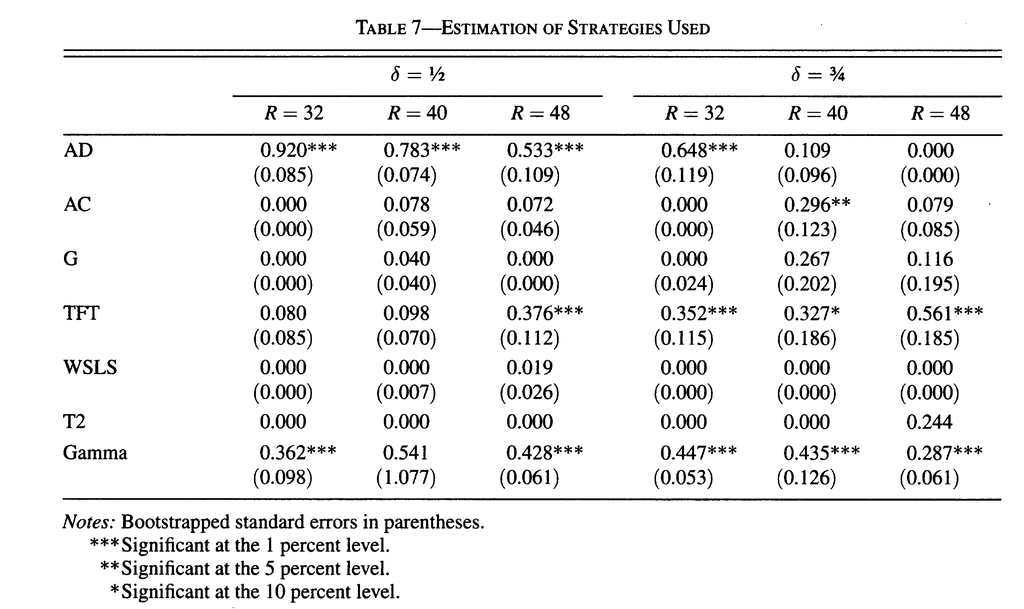

Table 7 of Dal Bó, Pedro, and Guillaume R. Fréchette. “The evolution of cooperation in infinitely repeated games: Experimental evidence.” American Economic Review 101, no. 1 (2011): 411-29.

The differences come largely from the prior over the mixing probabilities, which is a bit informative, so all of the estimates are going to be closer to the prior mean (1/6) that the maximum likelihood estimates.

See [here](https://sites.google.com/site/jamesbland/code-examples) for more of my coding examples!

# Appendix: Full model estimates

```r
T1$summary
```

```
##                 mean      se_mean          sd          2.5%           25%
## trmb      0.06042611 0.0001069824 0.008367417  4.525577e-02  5.446594e-02
## mix[1]    0.82967783 0.0006882121 0.052768212  7.136601e-01  7.972324e-01
## mix[2]    0.01974069 0.0002772477 0.019229199  5.423740e-04  5.890378e-03
## mix[3]    0.02030132 0.0002665060 0.019789395  5.030528e-04  5.840136e-03
## mix[4]    0.09095914 0.0005652863 0.041293046  2.743954e-02  6.068942e-02
## mix[5]    0.01985731 0.0002890933 0.019430385  5.313999e-04  5.933002e-03
## mix[6]    0.01946372 0.0002915112 0.019033580  4.713548e-04  5.773416e-03
## lp__   -227.37903586 0.0480933473 1.877874133 -2.319098e+02 -2.283822e+02
##                  50%           75%         97.5%    n_eff      Rhat
## trmb      0.06000334    0.06563086    0.07780279 6117.274 0.9993280
## mix[1]    0.83418713    0.86843776    0.91877546 5878.955 1.0000015
## mix[2]    0.01369164    0.02760549    0.07273062 4810.459 0.9995702
## mix[3]    0.01413639    0.02821384    0.07325309 5513.800 0.9992109
## mix[4]    0.08536702    0.11434270    0.18596537 5336.014 0.9998273
## mix[5]    0.01365423    0.02765227    0.07274370 4517.381 0.9993909
## mix[6]    0.01352040    0.02675884    0.07192032 4263.149 1.0001371
## lp__   -227.05179017 -225.99594571 -224.73640004 1524.625 1.0013503
```

```r
T2$summary
```

```
##                 mean      se_mean         sd          2.5%           25%
## trmb      0.13678215 0.0001258211 0.00978911  1.176817e-01  1.302326e-01
## mix[1]    0.71447008 0.0007830314 0.06092447  5.887141e-01  6.748734e-01
## mix[2]    0.08347022 0.0005744599 0.04082375  2.183423e-02  5.319611e-02
## mix[3]    0.05184880 0.0004761581 0.03247572  6.623970e-03  2.775885e-02
## mix[4]    0.10725704 0.0006312762 0.04398705  3.720118e-02  7.434664e-02
## mix[5]    0.02111856 0.0003000004 0.02005200  5.079780e-04  6.600522e-03
## mix[6]    0.02183531 0.0003283077 0.02143606  5.409721e-04  6.252745e-03
## lp__   -548.16319724 0.0445814948 1.89072344 -5.527103e+02 -5.492033e+02
##                  50%           75%         97.5%    n_eff      Rhat
## trmb      0.13674479    0.14315945    0.15644410 6053.122 0.9999757
## mix[1]    0.71798013    0.75722773    0.82466081 6053.761 0.9997904
## mix[2]    0.07744105    0.10771833    0.17980550 5050.175 0.9995667
## mix[3]    0.04545748    0.06950565    0.13078297 4651.738 0.9997449
## mix[4]    0.10207733    0.13454388    0.20758850 4855.242 0.9995445
## mix[5]    0.01520241    0.02994653    0.07460453 4467.572 0.9995509
## mix[6]    0.01518365    0.03101202    0.07662866 4263.124 1.0001306
## lp__   -547.81320994 -546.77197273 -545.59354537 1798.650 1.0001070
```

```r
T3$summary
```

```
##                 mean      se_mean          sd          2.5%           25%
## trmb      0.08899003 8.757503e-05 0.007429788  7.487497e-02  8.391497e-02
## mix[1]    0.49026297 8.744557e-04 0.070680344  3.466014e-01  4.439487e-01
## mix[2]    0.08399825 4.767685e-04 0.038892073  2.590547e-02  5.526191e-02
## mix[3]    0.03461899 4.259663e-04 0.032828717  1.015449e-03  1.059192e-02
## mix[4]    0.33173268 8.776353e-04 0.070324361  1.981695e-01  2.843501e-01
## mix[5]    0.03670452 3.583795e-04 0.026840554  2.660937e-03  1.670393e-02
## mix[6]    0.02268259 3.230511e-04 0.022021015  4.776545e-04  6.423729e-03
## lp__   -478.69589929 4.806719e-02 1.867179457 -4.834092e+02 -4.797373e+02
##                  50%           75%         97.5%    n_eff      Rhat
## trmb      0.08868523    0.09389093    0.10410568 7197.675 0.9994161
## mix[1]    0.49152751    0.53734786    0.62995697 6533.136 0.9993618
## mix[2]    0.07815956    0.10637911    0.17548339 6654.373 0.9995471
## mix[3]    0.02508343    0.04780821    0.12513123 5939.602 1.0002107
## mix[4]    0.32992536    0.37653100    0.47557975 6420.715 0.9999032
## mix[5]    0.03100792    0.05111468    0.10329143 5609.144 0.9993195
## mix[6]    0.01629994    0.03152899    0.08083814 4646.566 0.9995757
## lp__   -478.34586160 -477.28614812 -476.13041669 1508.949 1.0061079
```

```r
T4$summary
```

```
##                 mean      se_mean          sd          2.5%           25%
## trmb      0.09644303 9.803742e-05 0.007325154  8.234737e-02  9.146184e-02
## mix[1]    0.59095486 8.643220e-04 0.068023769  4.538593e-01  5.459541e-01
## mix[2]    0.02129521 2.586328e-04 0.020122658  7.180614e-04  6.754414e-03
## mix[3]    0.03321887 4.042856e-04 0.029287995  9.182787e-04  1.095065e-02
## mix[4]    0.31508998 8.690282e-04 0.066296085  1.941708e-01  2.674947e-01
## mix[5]    0.01995489 3.154938e-04 0.019829424  4.536896e-04  5.919203e-03
## mix[6]    0.01948619 2.769273e-04 0.019231610  4.538340e-04  5.495932e-03
## lp__   -553.94991536 4.933384e-02 1.870652026 -5.586376e+02 -5.548988e+02
##                  50%           75%         97.5%    n_eff      Rhat
## trmb      0.09645224    0.10125097    0.11169263 5582.770 0.9998312
## mix[1]    0.59302362    0.63768808    0.71725126 6193.986 0.9997442
## mix[2]    0.01519197    0.02985020    0.07473165 6053.459 0.9997937
## mix[3]    0.02507626    0.04768011    0.11002648 5248.108 1.0005016
## mix[4]    0.31256896    0.36059761    0.44633793 5819.799 0.9993670
## mix[5]    0.01364356    0.02787626    0.07123101 3950.378 1.0008111
## mix[6]    0.01355433    0.02694739    0.07104276 4822.805 0.9994133
## lp__   -553.61650432 -552.58363595 -551.33909902 1437.792 1.0028806
```

```r
T5$summary
```

```
##                 mean      se_mean          sd          2.5%           25%
## trmb      0.09260310 0.0001343174 0.009478853  7.519480e-02    0.08592130
## mix[1]    0.11767231 0.0006978206 0.049387563  4.045730e-02    0.08106145
## mix[2]    0.26691740 0.0012211118 0.092883139  1.040836e-01    0.20069767
## mix[3]    0.22505643 0.0013764330 0.093454392  6.014565e-02    0.15844359
## mix[4]    0.29962372 0.0016498417 0.109839585  1.087376e-01    0.22089484
## mix[5]    0.04465074 0.0006620600 0.042593458  1.127376e-03    0.01338055
## mix[6]    0.04607940 0.0006613875 0.043626996  1.287946e-03    0.01435935
## lp__   -330.72539783 0.0468507456 1.873803863 -3.352287e+02 -331.75191661
##                  50%           75%        97.5%    n_eff      Rhat
## trmb      0.09234199    0.09896211    0.1119184 4980.202 0.9997214
## mix[1]    0.11167475    0.14696242    0.2304880 5008.960 0.9996324
## mix[2]    0.26050771    0.32832133    0.4599101 5785.794 0.9991082
## mix[3]    0.21994354    0.28727995    0.4208924 4609.876 1.0008823
## mix[4]    0.29385931    0.37276345    0.5324372 4432.341 1.0001445
## mix[5]    0.03186216    0.06181721    0.1590610 4138.959 0.9996121
## mix[6]    0.03314864    0.06414102    0.1669380 4351.096 0.9995530
## lp__   -330.39137992 -329.32918760 -328.0913110 1599.614 1.0006951
```

```r
T6$summary
```

```
##                 mean      se_mean         sd          2.5%           25%
## trmb      0.03038437 0.0000635525 0.00454859  2.217356e-02  2.715860e-02
## mix[1]    0.01945892 0.0002706448 0.01862425  5.281101e-04  5.996457e-03
## mix[2]    0.11170877 0.0010015644 0.07050006  1.674551e-02  5.751698e-02
## mix[3]    0.14632260 0.0012759718 0.09705995  1.093470e-02  7.068211e-02
## mix[4]    0.45595843 0.0015393404 0.11733961  2.345935e-01  3.694747e-01
## mix[5]    0.05699302 0.0006986224 0.05195705  1.584109e-03  1.815349e-02
## mix[6]    0.20955825 0.0015650937 0.10851225  3.484882e-02  1.267084e-01
## lp__   -220.11122448 0.0441246949 1.81258943 -2.245965e+02 -2.210623e+02
##                  50%           75%         97.5%    n_eff      Rhat
## trmb      0.03011798    0.03343094    0.03976325 5122.576 0.9994307
## mix[1]    0.01402523    0.02689992    0.06999923 4735.416 1.0003339
## mix[2]    0.09589467    0.15394532    0.28136427 4954.743 0.9991331
## mix[3]    0.12957079    0.20609185    0.36542927 5786.261 1.0000210
## mix[4]    0.45627261    0.53948010    0.68472769 5810.586 0.9991274
## mix[5]    0.04249334    0.08058422    0.19327303 5531.005 0.9993940
## mix[6]    0.19853651    0.27972928    0.44838411 4807.030 0.9995196
## lp__   -219.78751953 -218.79829141 -217.55448530 1687.468 1.0017345
```

# Appendix: data wrangling etc.

```r
rm(list=ls())

library(foreign)
library(xtable)
library(ggplot2)
library(gganimate)
library(gifski)
library(png)
library("rstan") # observe startup messages
rstan_options(auto_write = TRUE)
Sys.setenv(LOCAL_CPPFLAGS = '-march=native')
options(mc.cores = parallel::detectCores())

DBFData<-data.frame()
for (ff in 1:6) {
  fname<-paste("dfformatlab_strg_",ff,"_special.txt",sep="")
  d<-data.frame(read.delim(fname, header = FALSE, sep = "\t", dec = "."))
  colnames(d)<-c("match","round","treatment","coop","id","ocoop_all","strg1","strg2","strg3","strg4","strg5","strg6","session","id2_all")
  DBFData<-rbind(DBFData,d)
}

for (ff in 1:6) {
  str<-paste("DBFData$follow",ff,"<- as.integer(DBFData$coop == DBFData$strg",ff,")",sep="")
  eval(parse(text=str))
}

# aggregate data to counts
AggData<-aggregate(DBFData[,c("follow1","follow2","follow3","follow4","follow5","follow6")], by=list(DBFData$id),FUN=sum)
colnames(AggData)[1]<-"id"
AggData$n<-aggregate(DBFData$id,by=list(DBFData$id),FUN=length)$x
AggData$Treatment<-aggregate(DBFData$treatment,by=list(DBFData$id),FUN=mean)$x
saveRDS(AggData,"DBFData.rds")

for (tt in 1:6) {
  D<-AggData[AggData$Treatment==tt,]
  FOLLOWS <- as.matrix(D[,c("follow1","follow2","follow3","follow4","follow5","follow6")])
  N<-dim(FOLLOWS)[1]
  S<-dim(FOLLOWS)[2]
  COUNTS  <- as.matrix(D$n) %*% matrix(1,1,S)
  priorMix <-c(1, 1, 1, 1, 1, 1)

  d = list(FOLLOWS=FOLLOWS,N=N,S=S,COUNTS=COUNTS,priorMix=priorMix)

  Fit<-stan("SFEM.stan",data=d,seed=42,control = list(adapt_delta = 0.8))
  saveRDS(Fit,file=paste("SFEM",tt,".rds",sep=""))
}
```